# Credit Card Customer Segmentation

#### K-means Clustering:

```python
# Scale the data
# Using zscore

from scipy.stats import zscore
ccd_s = ccd.apply(zscore)
```

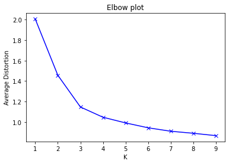

```python
# Finding optimal number of K

# Importing cdist to find distance between two points, in this case centroids
from scipy.spatial.distance import cdist
cluster = range(1,10)
AvgDist = [] #Mean distortion is initialized
totRows = ccd_s.shape[0]

for k in cluster:
    model = KMeans(n_clusters = k)
    model.fit(ccd_s)
    prediction = model.predict(ccd_s)
    # Distance to all clusters
    dist_all = cdist(ccd_s,model.cluster_centers_,'euclidean')
    # Distance to own cluster
    dist_own = np.min(dist_all,axis=1)
    # Calculate Average Distortion and append to array
    AvgDist.append(sum(dist_own)/totRows)


# Elbow plot - K vs Average Distortions
plt.plot(cluster,AvgDist,'bx-')
plt.xlabel('K')
plt.ylabel('Average Distortion')
plt.title('Elbow plot')
```

```python
# Calculating Silhouette score for various values of K from 1 to 10

from sklearn.metrics import silhouette_score
for i in range(2,10):
    labels = KMeans(n_clusters=i).fit(ccd_s).labels_
    KMeansSilhouette = silhouette_score(ccd_s,labels,metric="euclidean")
    print ('The Silhouette score for K=',i,' is: ',KMeansSilhouette)
```

```
The Silhouette score for K= 2  is:  0.41842496663215445
The Silhouette score for K= 3  is:  0.5157182558881063
The Silhouette score for K= 4  is:  0.3556670619372605
The Silhouette score for K= 5  is:  0.2720035371775218
The Silhouette score for K= 6  is:  0.25545029453623114
The Silhouette score for K= 7  is:  0.24858093056433223
The Silhouette score for K= 8  is:  0.22745772081787835
The Silhouette score for K= 9  is:  0.21425119485236535
```

##### Silhouette score is better when it's close to 1 and worse when it's close to -1. Hence, based on elbow plot as well as silhouette score, we are choosing K = 3

```python
# Setting K as 3
model = KMeans(n_clusters=3,random_state = 7)
model.fit(ccd_s)
predictionK3 = model.predict(ccd_s)
```

```python
# Adding the predicted group to the unscaled data for easy interpretation

ccd['KMeans_group'] = predictionK3
ccd.head()
```

|  | Avg_Credit_Limit | Total_Credit_Cards | Total_visits_bank | Total_visits_online | Total_calls_made | KMeans_group |
| --- | --- | --- | --- | --- | --- | --- |
| 0 | 100000 | 2 | 1 | 1 | 0 | 0 |
| 1 | 50000 | 3 | 0 | 10 | 9 | 1 |
| 2 | 50000 | 7 | 1 | 3 | 4 | 0 |
| 3 | 30000 | 5 | 1 | 1 | 4 | 0 |
| 4 | 100000 | 6 | 0 | 12 | 3 | 2 |

```python
ccd_s.head()
```

|  | Avg_Credit_Limit | Total_Credit_Cards | Total_visits_bank | Total_visits_online | Total_calls_made |
| --- | --- | --- | --- | --- | --- |
| 0 | 1.740187 | -1.249225 | -0.860451 | -0.547490 | -1.251537 |
| 1 | 0.410293 | -0.787585 | -1.473731 | 2.520519 | 1.891859 |
| 2 | 0.410293 | 1.058973 | -0.860451 | 0.134290 | 0.145528 |
| 3 | -0.121665 | 0.135694 | -0.860451 | -0.547490 | 0.145528 |
| 4 | 1.740187 | 0.597334 | -1.473731 | 3.202298 | -0.203739 |

```python
# Data insight from KMeans_group
ccd.groupby(by='KMeans_group').agg([np.mean,min,max]).transpose()
```

|  | KMeans_group | 0 | 1 | 2 |
| --- | --- | --- | --- | --- |
| Avg_Credit_Limit | mean | 33782.383420 | 12174.107143 | 141040.00 |
|  | min | 5000.000000 | 3000.000000 | 84000.00 |
|  | max | 100000.000000 | 50000.000000 | 200000.00 |
| Total_Credit_Cards | mean | 5.515544 | 2.410714 | 8.74 |
|  | min | 2.000000 | 1.000000 | 5.00 |
|  | max | 7.000000 | 4.000000 | 10.00 |
| Total_visits_bank | mean | 3.489637 | 0.933036 | 0.60 |
|  | min | 1.000000 | 0.000000 | 0.00 |
|  | max | 5.000000 | 2.000000 | 1.00 |
| Total_visits_online | mean | 0.981865 | 3.553571 | 10.90 |
|  | min | 0.000000 | 1.000000 | 6.00 |
|  | max | 3.000000 | 10.000000 | 15.00 |
| Total_calls_made | mean | 2.000000 | 6.870536 | 1.08 |
|  | min | 0.000000 | 1.000000 | 0.00 |
|  | max | 4.000000 | 10.000000 | 3.00 |

```
array([[<matplotlib.axes._subplots.AxesSubplot object at 0x00000281A79416D0>,
      dtype=object)
```

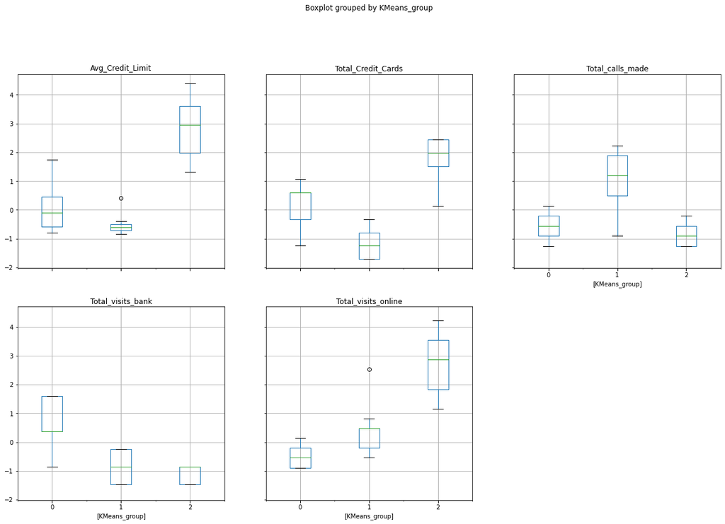

```python
# Boxplot for clusters. Using scaled data for effective visualization
ccd_s['KMeans_group'] = predictionK3
ccd_s.boxplot(by=['KMeans_group'],layout=(3,3),figsize=(20,20))
```

#### Hierarchical Clustering:

```python
# Removing KMeans_group column from scaled dataframe
ccd_s.drop('KMeans_group',inplace=True,axis=1)
ccd_s.head()
```

|  | Avg_Credit_Limit | Total_Credit_Cards | Total_visits_bank | Total_visits_online | Total_calls_made |
| --- | --- | --- | --- | --- | --- |
| 0 | 1.740187 | -1.249225 | -0.860451 | -0.547490 | -1.251537 |
| 1 | 0.410293 | -0.787585 | -1.473731 | 2.520519 | 1.891859 |
| 2 | 0.410293 | 1.058973 | -0.860451 | 0.134290 | 0.145528 |
| 3 | -0.121665 | 0.135694 | -0.860451 | -0.547490 | 0.145528 |
| 4 | 1.740187 | 0.597334 | -1.473731 | 3.202298 | -0.203739 |

```python
# Using Linkage method
# Importing relevant metrics

from scipy.cluster.hierarchy import cophenet, dendrogram, linkage
from scipy.spatial.distance import pdist
```

1. 'Ward' Linkage:

```python
# Calculating cophenetic coefficient:
ZW = linkage(ccd_s, metric='euclidean', method='ward')
cW, coph_dist = cophenet(ZW , pdist(ccd_s))

print('Cophenetic coefficient for Ward linkage = ', cW)
```

```
Cophenetic coefficient for Ward linkage =  0.7415156284827493
```

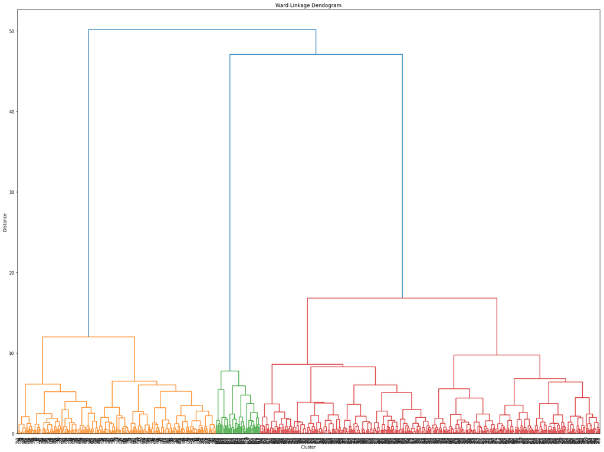

```python
# Plotting Dendrogram:
plt.figure(figsize=(20, 15))
plt.title('Ward Linkage Dendogram')
plt.xlabel('Cluster')
plt.ylabel('Distance')
dendrogram(ZW, leaf_rotation=90.,color_threshold = 40, leaf_font_size=8. )
plt.tight_layout()
```

It can be observed from the dendrogram above that the large variance in distance is for the last 3 clusters.

2.'Average' Linkage:

```python
# Calculating cophenetic coefficient:
ZA = linkage(ccd_s, metric='euclidean', method='average')
cA, coph_dist = cophenet(ZA , pdist(ccd_s))

print('Cophenetic coefficient for Average linkage = ', cA)
```

```
Cophenetic coefficient for Average linkage =  0.8977080867389372
```

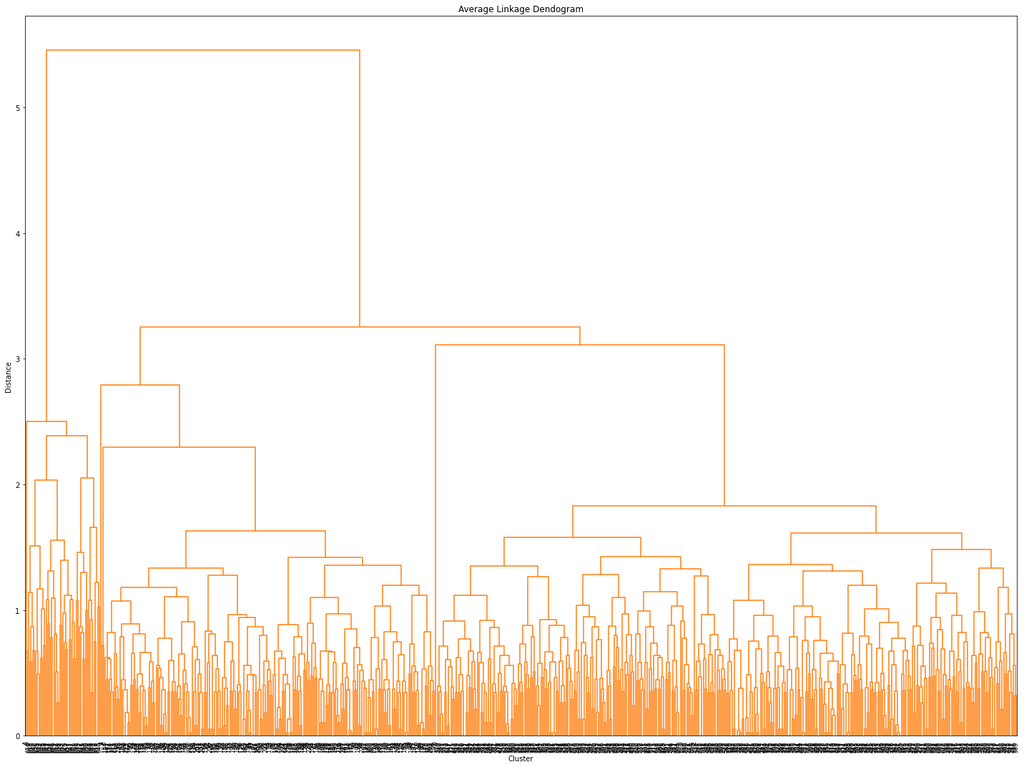

```python
# Plotting Dendrogram:
plt.figure(figsize=(20, 15))
plt.title('Average Linkage Dendogram')
plt.xlabel('Cluster')
plt.ylabel('Distance')
dendrogram(ZA, leaf_rotation=90.,color_threshold = 40, leaf_font_size=8. )
plt.tight_layout()
```

Cophenetic coefficient for Average is higher than Ward linkage for our data. It can be observed from the dendrogram that the large variance is in the last 2 clusters. But, we need to take into account the other large variance right most cluster as well. If a max distance has to be chosen for clustering, we should look at distance > 3 which will give us 3 clusters. This will include the large variance in the right most cluster as well.

1. 'Centroid' Linkage:

```python
# Calculating cophenetic coefficient:
ZC = linkage(ccd_s, metric='euclidean', method='centroid')
cC, coph_dist = cophenet(ZC , pdist(ccd_s))

print('Cophenetic coefficient for Centroid linkage = ', cC)
```

```
Cophenetic coefficient for Centroid linkage =  0.8939385846326323
```

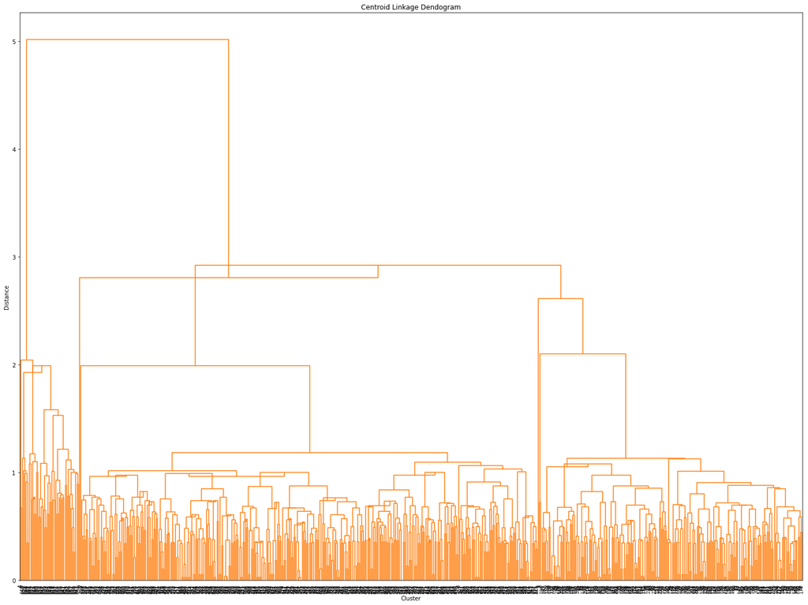

```python
# Plotting Dendrogram:
plt.figure(figsize=(20, 15))
plt.title('Centroid Linkage Dendogram')
plt.xlabel('Cluster')
plt.ylabel('Distance')
dendrogram(ZC, leaf_rotation=90.,color_threshold = 40, leaf_font_size=8. )
plt.tight_layout()
```

1. 'Complete' Linkage:

```python
# Calculating cophenetic coefficient:
ZCo = linkage(ccd_s, metric='euclidean', method='complete')
cCo, coph_dist = cophenet(ZCo , pdist(ccd_s))

print('Cophenetic coefficient for Complete linkage = ', cCo)
```

```
Cophenetic coefficient for Complete linkage =  0.8599730607972423
```

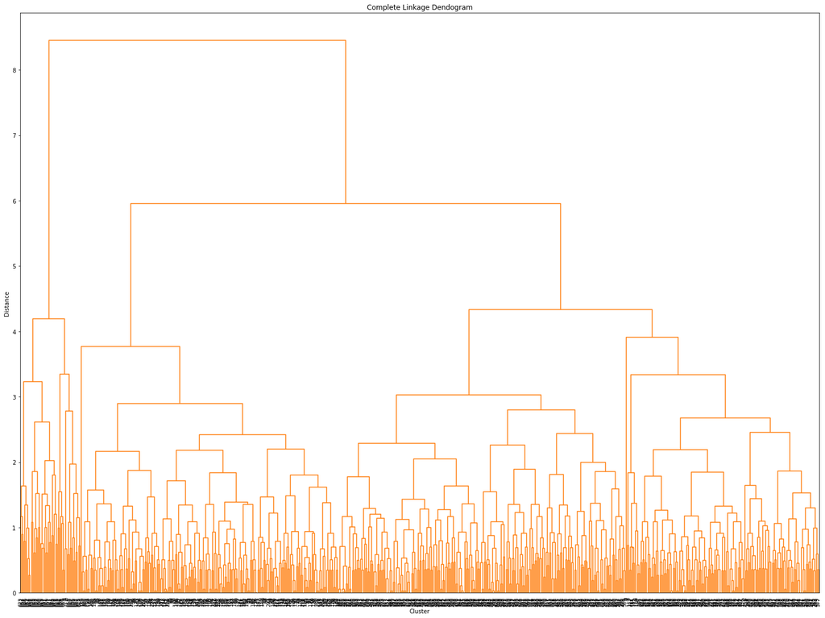

```python
# Plotting Dendrogram:
plt.figure(figsize=(20, 15))
plt.title('Complete Linkage Dendogram')
plt.xlabel('Cluster')
plt.ylabel('Distance')
dendrogram(ZCo, leaf_rotation=90.,color_threshold = 40, leaf_font_size=8. )
plt.tight_layout()
```

Cophenetic coefficient is lesser than 'Average' linkage's coeff. But this clustering seems more efficient. The distance variance is more even across various clusters. The max distance can be drawn at 5 which will give us 3 clusters.

##### Choosing a 'linkage' method to use for prediction:

Between the 4 linkage methods we have used, 'Average' has the highest cophenetic coefficient closer to 1 followed by 'Centroid', 'Complete' and 'Ward'.

But as noted above, the clustering of 'Complete' seems to have even variance across the various clusters. I will use both 'Average' and 'Complete' to cluster the data and see which has the highest silhouette score.

Using 'Average' linkage to create clusters:

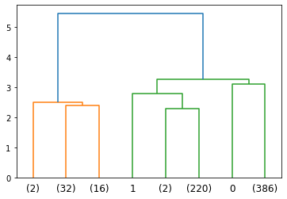

```python
#Truncating 'Average' linkage dendrogram to observe in detail
dendrogram(ZA,truncate_mode='lastp',p=8)
plt.show()
```

From above truncated dendrogram for 'Average' linkage, it can be seen that the right most cluster already had 386 records before 8 clusters. We will set max_d = 3.2 to cluster the data into 3 groups.

```python
# max_d from Average Linkage
max_dA = 3.2
```

```python
# Using max_dA to cluster the data into different groups

from scipy.cluster.hierarchy import fcluster
clustersA = fcluster(ZA, max_dA, criterion='distance')
clustersA
```

```
array([3, 2, 3, 3, 1, 2, 1, 2, 2, 2, 2, 2, 2, 2, 2, 2, 2, 2, 2, 2, 2, 2,
       2, 2, 2, 2, 2, 2, 2, 2, 2, 2, 2, 2, 2, 2, 2, 2, 2, 2, 2, 2, 2, 2,
       2, 2, 2, 2, 2, 2, 2, 2, 2, 2, 2, 2, 2, 2, 2, 2, 2, 2, 2, 2, 2, 2,
       2, 2, 2, 2, 2, 2, 2, 2, 2, 2, 2, 2, 2, 2, 2, 2, 2, 2, 2, 2, 2, 2,
       2, 2, 2, 2, 2, 2, 2, 2, 2, 2, 2, 2, 2, 2, 2, 2, 2, 2, 2, 2, 2, 2,
       2, 2, 2, 2, 2, 2, 2, 2, 2, 2, 2, 2, 2, 2, 2, 2, 2, 2, 2, 2, 2, 2,
       2, 2, 2, 2, 2, 2, 2, 2, 2, 2, 2, 2, 2, 2, 2, 2, 2, 2, 2, 2, 2, 2,
       2, 2, 2, 2, 2, 2, 2, 2, 2, 2, 2, 2, 2, 2, 2, 2, 2, 2, 2, 2, 2, 2,
       2, 2, 2, 2, 2, 2, 2, 2, 2, 2, 2, 2, 2, 2, 2, 2, 2, 2, 2, 2, 2, 2,
       2, 2, 2, 2, 2, 2, 2, 2, 2, 2, 2, 2, 2, 2, 2, 2, 2, 2, 2, 2, 2, 2,
       2, 2, 2, 2, 2, 2, 2, 2, 3, 3, 3, 3, 3, 3, 3, 3, 3, 3, 3, 3, 3, 3,
       3, 3, 3, 3, 3, 3, 3, 3, 3, 3, 3, 3, 3, 3, 3, 3, 3, 3, 3, 3, 3, 3,
       3, 3, 3, 3, 3, 3, 3, 3, 3, 3, 3, 3, 3, 3, 3, 3, 3, 3, 3, 3, 3, 3,
       3, 3, 3, 3, 3, 3, 3, 3, 3, 3, 3, 3, 3, 3, 3, 3, 3, 3, 3, 3, 3, 3,
       3, 3, 3, 3, 3, 3, 3, 3, 3, 3, 3, 3, 3, 3, 3, 3, 3, 3, 3, 3, 3, 3,
```

[output cut: 16 more lines]

```python
# Calculate Avg Silhoutte Score for 'Average' linkage

silhouette_score(ccd_s,clustersA)
```

```
0.515922432650965
```

Using 'Complete' Linkage to create clusters:

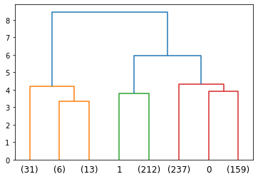

```python
#Truncating 'Complete' linkage dendrogram to observe in detail
dendrogram(ZCo,truncate_mode='lastp',p=8)
plt.show()
```

```python
# max_d from Complete Linkage
max_dC = 5
```

```python
# Using max_dC to cluster the data into different groups

clustersC = fcluster(ZCo, max_dC, criterion='distance')
clustersC
```

```
array([3, 2, 3, 3, 1, 2, 1, 3, 3, 2, 2, 2, 2, 2, 2, 2, 2, 2, 2, 2, 2, 2,
       2, 2, 2, 2, 2, 2, 2, 2, 2, 2, 2, 2, 2, 2, 2, 2, 2, 2, 2, 2, 2, 2,
       2, 2, 2, 2, 2, 2, 2, 2, 2, 2, 2, 2, 2, 2, 2, 2, 2, 2, 2, 2, 2, 2,
       2, 2, 2, 2, 2, 2, 2, 2, 2, 2, 2, 2, 2, 2, 2, 2, 2, 2, 2, 2, 2, 3,
       2, 2, 2, 2, 2, 2, 2, 2, 2, 2, 2, 2, 2, 2, 2, 2, 2, 2, 2, 2, 2, 2,
       2, 2, 2, 3, 2, 2, 2, 2, 2, 2, 2, 2, 2, 2, 2, 2, 2, 2, 2, 2, 2, 3,
       3, 2, 2, 2, 2, 2, 2, 2, 2, 2, 2, 2, 2, 2, 2, 2, 2, 2, 2, 2, 2, 2,
       2, 2, 2, 2, 2, 2, 2, 2, 2, 2, 2, 2, 2, 2, 2, 2, 2, 2, 2, 2, 2, 2,
       2, 2, 2, 2, 2, 2, 2, 2, 3, 2, 2, 2, 2, 2, 2, 2, 3, 2, 2, 2, 2, 2,
       2, 2, 2, 2, 2, 2, 2, 2, 2, 2, 2, 2, 2, 2, 2, 2, 2, 2, 2, 3, 2, 2,
       2, 2, 2, 2, 2, 3, 2, 2, 3, 3, 3, 3, 3, 3, 3, 3, 3, 3, 3, 3, 3, 3,
       3, 3, 3, 3, 3, 3, 3, 3, 3, 3, 3, 3, 3, 3, 3, 3, 3, 3, 3, 3, 3, 3,
       3, 3, 3, 3, 3, 3, 3, 3, 3, 3, 3, 3, 3, 3, 3, 3, 3, 3, 3, 3, 3, 3,
       3, 3, 3, 3, 3, 3, 3, 3, 3, 3, 3, 3, 3, 3, 3, 3, 3, 3, 3, 3, 3, 3,
       3, 3, 3, 3, 3, 3, 3, 3, 3, 3, 3, 3, 3, 3, 3, 3, 3, 3, 3, 3, 3, 3,
```

[output cut: 16 more lines]

```python
# Calculate Avg Silhoutte Score for 'Complete' linkage

silhouette_score(ccd_s,clustersC)
```

```
0.5026435522438492
```

##### Final hierarchical clustering linkage:

Based on the silhouette score, we will use 'Average' linkage cluster labels.

```python
# Adding Hierarchical grouping to unscaled data for interpretation

ccd['HC_group'] = clustersA
ccd.head()
```

|  | Avg_Credit_Limit | Total_Credit_Cards | Total_visits_bank | Total_visits_online | Total_calls_made | KMeans_group | HC_group |
| --- | --- | --- | --- | --- | --- | --- | --- |
| 0 | 100000 | 2 | 1 | 1 | 0 | 0 | 3 |
| 1 | 50000 | 3 | 0 | 10 | 9 | 1 | 2 |
| 2 | 50000 | 7 | 1 | 3 | 4 | 0 | 3 |
| 3 | 30000 | 5 | 1 | 1 | 4 | 0 | 3 |
| 4 | 100000 | 6 | 0 | 12 | 3 | 2 | 1 |

```python
# Data insight from KMeans_group
ccd.groupby(by='HC_group').agg([np.mean,min,max]).transpose()
```

|  | HC_group | 1 | 2 | 3 |
| --- | --- | --- | --- | --- |
| Avg_Credit_Limit | mean | 141040.00 | 12197.309417 | 33713.178295 |
|  | min | 84000.00 | 3000.000000 | 5000.000000 |
|  | max | 200000.00 | 50000.000000 | 100000.000000 |
| Total_Credit_Cards | mean | 8.74 | 2.403587 | 5.511628 |
|  | min | 5.00 | 1.000000 | 2.000000 |
|  | max | 10.00 | 4.000000 | 7.000000 |
| Total_visits_bank | mean | 0.60 | 0.928251 | 3.485788 |
|  | min | 0.00 | 0.000000 | 1.000000 |
|  | max | 1.00 | 2.000000 | 5.000000 |
| Total_visits_online | mean | 10.90 | 3.560538 | 0.984496 |
|  | min | 6.00 | 1.000000 | 0.000000 |
|  | max | 15.00 | 10.000000 | 3.000000 |
| Total_calls_made | mean | 1.08 | 6.883408 | 2.005168 |
|  | min | 0.00 | 1.000000 | 0.000000 |
|  | max | 3.00 | 10.000000 | 4.000000 |
| KMeans_group | mean | 2.00 | 1.000000 | 0.002584 |
|  | min | 2.00 | 1.000000 | 0.000000 |
|  | max | 2.00 | 1.000000 | 1.000000 |

```
array([[<matplotlib.axes._subplots.AxesSubplot object at 0x00000281A68983D0>,
      dtype=object)
```

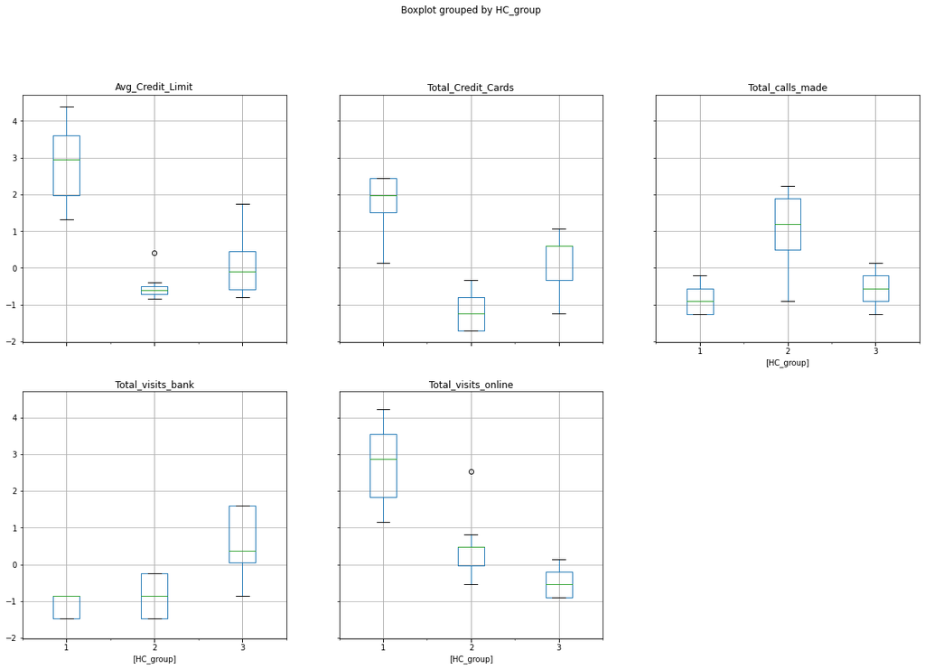

```python
# Boxplot for clusters. Using scaled data for effective visualization

ccd_s['HC_group'] = clustersA
ccd_s.boxplot(by=['HC_group'],layout=(3,3),figsize=(20,20))
```

##### Insights:

```python
# Clearing HC_group from scaled data:
ccd_s.drop('HC_group',inplace=True,axis=1)
ccd_s.head()
```

|  | Avg_Credit_Limit | Total_Credit_Cards | Total_visits_bank | Total_visits_online | Total_calls_made |
| --- | --- | --- | --- | --- | --- |
| 0 | 1.740187 | -1.249225 | -0.860451 | -0.547490 | -1.251537 |
| 1 | 0.410293 | -0.787585 | -1.473731 | 2.520519 | 1.891859 |
| 2 | 0.410293 | 1.058973 | -0.860451 | 0.134290 | 0.145528 |
| 3 | -0.121665 | 0.135694 | -0.860451 | -0.547490 | 0.145528 |
| 4 | 1.740187 | 0.597334 | -1.473731 | 3.202298 | -0.203739 |